# Protagonismo programático e Migração Partidária: uma análise da 56ª Legislatura da Câmara dos Deputados

Vinícius Tejadas

2024-09-06

## Introdução

Considerando que os procedimentos eleitorais não são a única fonte de poder legislativo dos partidos políticos, e que outros fenômenos, alheios às vias eleitorais, podem impactar na correlação de forças no Parlamento, propõe-se, como objeto de pesquisa, o fenômeno da migração partidária, dando especial ênfase aos padrões de migração que emergem a partir dos distintos papéis legislativos que circunscrevem a atuação parlamentar no Poder Legislativo.

Inserida no marco da democracia representativa, o objeto de pesquisa – a migração partidária - é aqui entendido como a mudança de filiação partidária empreendida por pessoa regularmente filiada a uma sigla. Para este trabalho, entretanto, será dada ênfase à troca de partido empreendida durante o exercício do mandato eletivo – ou seja, ao deputado que migra de legenda entre a sua eleição e o último dia da legislatura em que foi investido. A perspectiva aqui adotada parte de Heller e Mershon (2009), que consideram como migração partidária toda mudança de filiação que envolva: (a) a migração entre dois partidos pré-existentes; (b) a fissão, em que um partido se divide entre dois ou mais; (c) a fusão, em que dois ou mais partidos se fundem em um; e (d) a criação, em que os parlamentares migram para um partido recém-constituído.

A literatura em ciência política, nos últimos anos, vem buscando entender as causas da migração partidária, dando especial enfoque ao parlamentar e suas motivações para a escolha de migrar. Instrumentalizando a teoria da escolha de Müller e Strøm (1999), em que os partidos, instados por seus líderes, agem a partir de motivações relacionadas à busca por cargos (office-seeking), votos (vote-seeking) ou políticas específicas (policy-seeking), muitos autores exploraram as motivações por trás da migração partidária a partir do posicionamento dos parlamentares em relação a uma dessas três categorias.

Nesse linha, Desposato (2006) pontuou que os acessos a cargos, votos ou políticas específicas interagem em um mesmo contexto – os deputados instrumentalizam partidos para maximizar suas chances de reeleição, seu acesso a cargos e recursos e, também, para afinar sua posição ideológica em relação a do seu partido. Isso se daria em razão de serem os partidos as figuras centrais na representação, distribuindo recursos, melhorando ou piorando prognósticos eleitorais e indicando como devem se portar seus parlamentares. Radean (2021), de sua sorte, questiona a dificuldade da literatura em explicar por que um fator é relevante em determinado cenário e irrelevante em outro, defendendo que as motivações para a migração partidária são substitutivas e interagem ativamente umas com as outras – ou seja, em diferentes contextos, a interação entre as possíveis motivações para a migração partidária – office, policy e vote-seeking – alteram a relevância de cada um dos fatores para a decisão política de mudar de legenda.

Neste relatório, entretanto, busco enfatizar as motivações policy-seeking para a migração partidária, sobretudo a partir dos padrões de atuação legislativa dos deputados. Em sua teoria sobre o papel legislativo dos parlamentares (“legislative roles”), Wahlke (1962, p. 16) aduz que os representantes, não raro, se posicionam no Parlamento a partir de diferentes orientações comportamentais (“role orientations”), que se referem às “diferenças sistemáticas nas concepções dos legisladores em relação a componentes particulares do papel de legislador”. Ou seja, sustenta que os atores podem desempenhar papéis distintos dentro de uma mesma organização – nesse caso, o Parlamento. O autor alerta, todavia, que os diferentes papéis não devem ser vistos como atributos estanques, que indicam e preveem de forma determinista as atitudes tomadas pelo parlamentar, mas que devem ser vistos como um conjunto de papéis (“role set”) que podem ser desempenhados por determinado legislador – isto é, agregando comportamentos distintos dentro de um mesmo arsenal de funções desempenhadas pelo representante. Na perspectiva de Strøm (2012, p. 87), os papéis legislativos desempenhados pelos políticos são estratégias rotinizadas, motivadas pela razão (preferências) e constrangidas pelas regras – ou seja, fazem parte de uma estratégia racional, que busca maximizar as chances de se atingir determinado objetivo político. Nessa senda, neste trabalho, se busca situar o fenômeno da migração partidária dentro do parlamento, relacionado às diferenças nos papéis legislativos desempenhados pelos representantes - em específico, as relacionada à atuação programática. Assim, propõe-se duas questões de pesquisa: (a) Existe uma relação significativa entre o protagonismo programático e a migração partidária? (b) Qual a diferença no protagonismo programático entre deputados que migraram e os que não migraram?

A partir das questões de pesquisa, neste trabalho, traça-se como objetivos:

1. Analisar a relação entre o protagonismo programático e os padrões de migração partidária na Câmara dos Deputados;
2. Criar índice de protagonismo programático a partir da Análise de Componentes Principais (PCA);
3. Empreender testes estatísticos para entender a relação entre as duas variáveis (regressão logística e diferença entre médias).

Ante os objetivos aqui propostos, abordar o fenômeno da migração partidária e sua relação com os diferentes papéis desempenhados pelos parlamentes no Legislativo pode contribuir para a literatura que estuda as identidades e os sistemas partidários como fluídos e endógenos, em contraposição a esquemas fixos e somente exógenos, possibilitando novas perspectivas em relação às dinâmicas e evoluções dos sistemas de partidos. De modo geral, a compreensão do fenômeno pode, ainda, iluminar inexplorados ângulos sobre o papel dos partidos na organização dos legislativos, na governança e na competição partidária nas e entre as eleições (Heller e Mershon, 2009). Além disso, buscar dentro dos padrões de atuação dos parlamentares as chaves para compreender a migração partidária pode trazer luz ao papel das dinâmicas próprias do poder legislativo no fenômeno, reforçando a perspectiva de que os acessos ou bloqueios encontrados durante o exercício do mandato parlamentar, mais do que incentivos exógenos ao parlamento, podem ser fortemente explicativos da decisão de mudar de partido.

## Hipótese

- H1: Parlamentares com altos níveis de protagonismo programático tem menos chances de migrar de partido.

## Método

### Coleta dos Dados

- Os dados relacionados à construção do índice de protagonismo programático foram coletados da plataforma de Dados Abertos da Câmara dos Deputados;
- Os dados relacionados à migração partidária foram acessados via pedido de acesso à informação e fornecidos pela Câmara dos Deputados em formato excel.

### O índice de protagonismo programático

O índice de protagonismo programático visa capturar a exposição do parlamentar quanto à discussão programática dentro do Parlamento – isto é, o quanto o parlamentar se envolve com pautas temáticas e ideológicas, manifestando características atinentes ao perfil *policy-seeking.* Para mensurar essa categoria, foram selecionados três indicadores relacionados à produção legislativa e à discussão de matérias temáticas. O quadro abaixo sumariza as variáveis utilizadas e sua operacionalização.

| Indicador | Operacionalização |
| --- | --- |
| Requerimentos de audiência pública | Numérica contínua |
| Autoria de projetos de lei e lei complementar | Numérica contínua |
| Coordenação de Frente Temática | Numérica contínua |

Entre os indicadores, está a autoria de projetos de lei, variável numérica contínua, que busca identificar quantos projetos de lei foram apresentados por cada parlamentar dentro do marco temporal de análise (uma sessão legislativa) – nesse caso, serão considerados apenas Projetos de Lei (PL) e Projetos de Lei Complementar (PLP), que podem ser apresentados individualmente pelos representantes, sem exigências quanto ao número de assinaturas necessárias.

Outro indicador selecionada foi a apresentação de requerimentos de audiência pública – as audiências públicas são propostas para debater temas salientes na sociedade, com a participação de experts, membros da sociedade civil e representantes de órgãos públicos. A variável indica afeição temática do parlamentar e responsividade às demandas programáticas das suas bases de apoio.

Por fim, o indicador “coordenação de frente temática” busca, de mesmo modo, identificar a afeição do parlamentar a alguma pauta específica – a criação de Frente Parlamentar no Congresso brasileiro exige e assinatura de outros membros do Parlamento, dedicando-se à proposição e discussão de temas de interesse do representante.

Para a construção do dataframe, cada deputado corresponde a uma observação, com colunas que representam a soma de audiências públicas, autoria de projetos ou de frentes coordenadas pelo parlamentar.

### Manipulação dos dados

Os dados que constituem as variáveis “audiência pública”, “autoria de PL e PLP” e “coordenação de frente parlamentar” foram agregados em números absolutos para cada parlamentar dentro da 56ª legislatura. A partir dos valores atribuídos a cada parlamentar, procedeu-se à Análise de Componentes Principais para elaboração do índice de protagonismo programático. Os gráficos a seguir representam a distribuição das variáveis a partir do z-valor.

#### Distribuição dos deputados em relação à variável “audiencias_publicas”

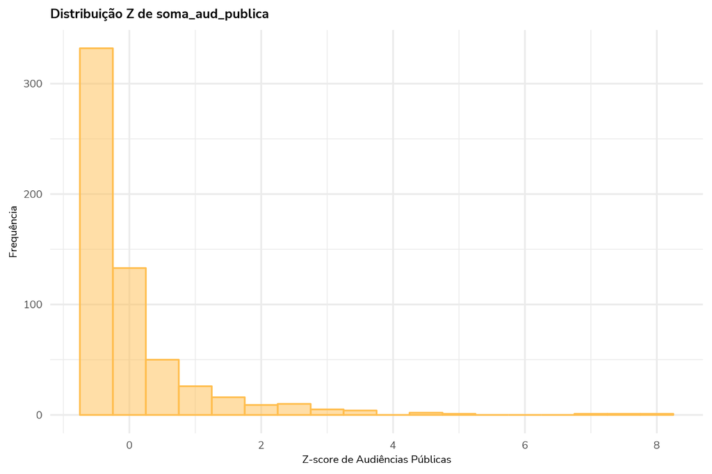

#### Distribuição dos deputados em relação à variável “autoria de PL e PLP”

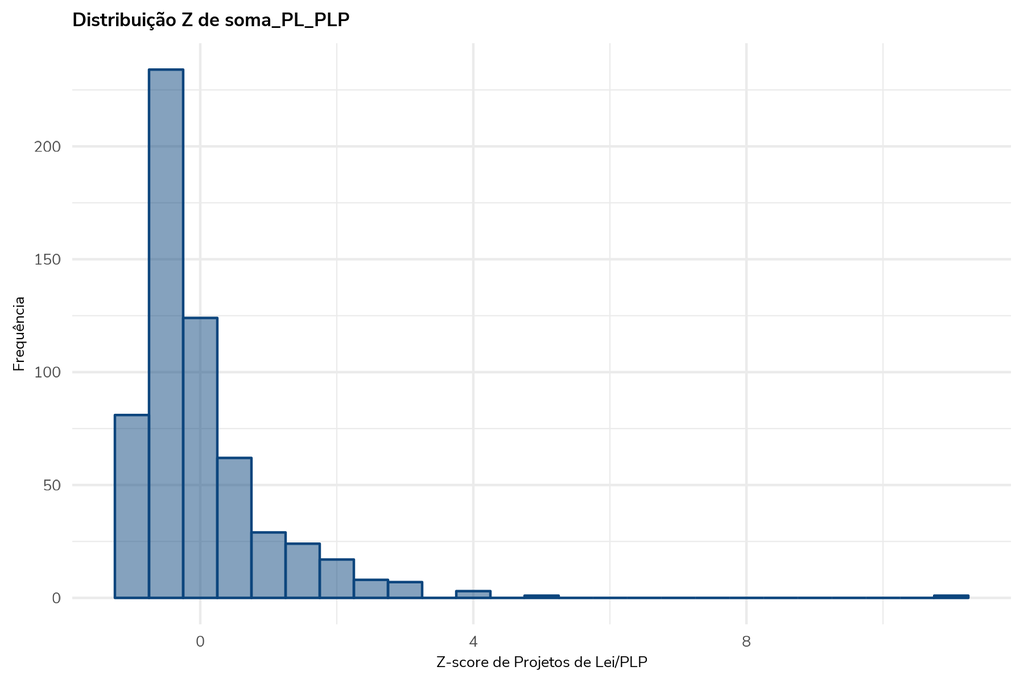

#### Distribuição dos deputados em relação à variável “coordenação de frente parlamentar”

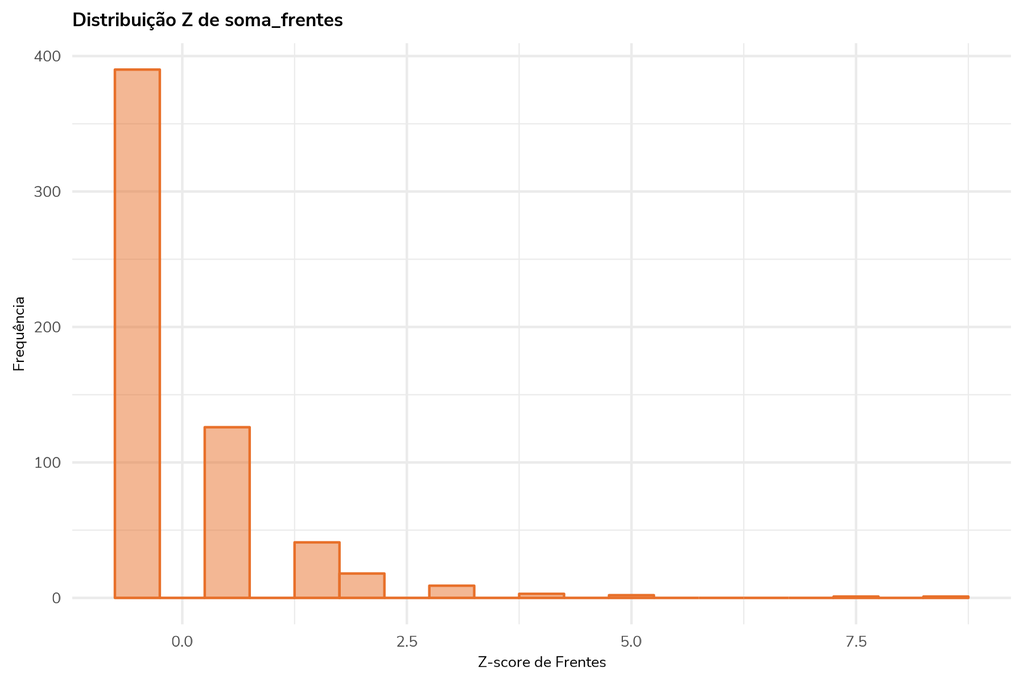

## Análise de Componentes Principais

- Para criar o índice de protagonismo, utilizou-se a Análise de Componentes Principais para reduzir o número de variáveis a um único índice representativo do conjunto de variáveis. O gráfico a seguir apresenta a variância explicada pelo PCA das três variáveis que compõem o índice de protagonismo programático.

#### Variância explicada pelas variáveis utilizadas no PCA

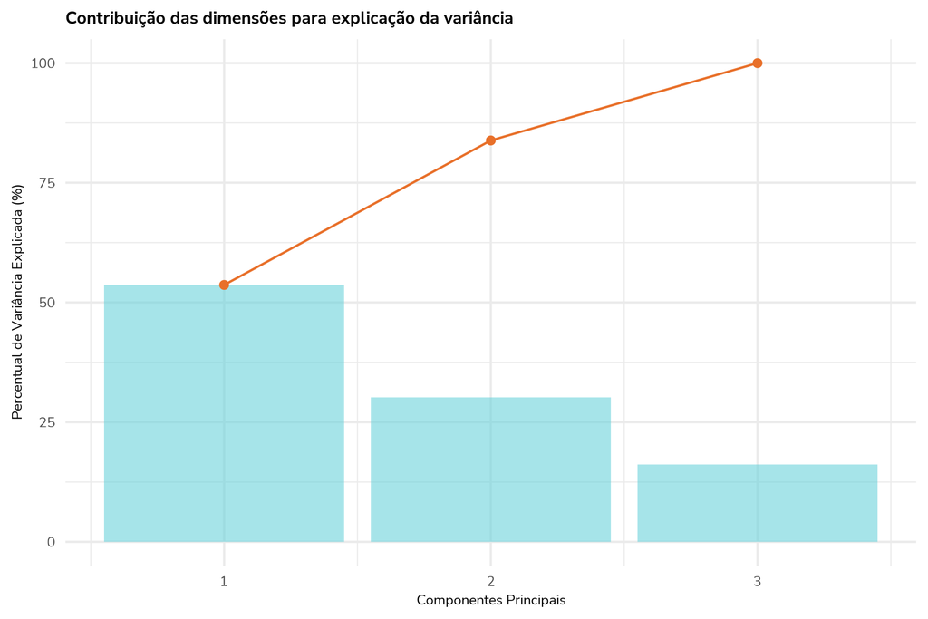

### Criação do índice a partir do PCA

- Uma vez que o “eigenvalue” foi calculado para cada uma das observações, foi realizada a média ponderada do valor atribuído a cada deputado, considerando os distintos pesos resultantes do PCA.
- Em uma segunda etapa, o valor resultante da média ponderada foi normalizado para que ficasse entre 0 e 1, facilitando a análise e a comparação dos dados entre os parlamentares.

#### Distribuição dos parlamentares em relação ao índice de protagonismo programático

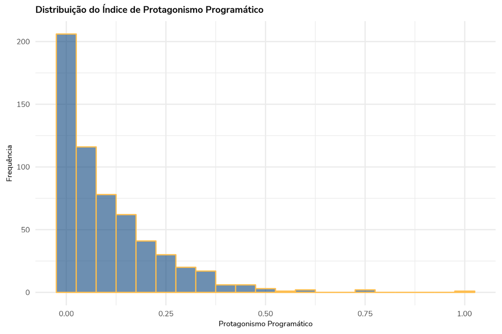

## Codificando deputados migrantes

- Para entender os efeitos do protagonismo na migraçao partidária, os deputados que trocaram de partido na 56ª legislatura foram codificados como 1 e os não migrantes como 0.
- Considerando que a variável dependente (migração) é uma dummy, a regressão logística torna-se o modelo mais adequado para o teste da hipótese (níveis mais altos de protagonismo posicional diminuem a probabilidade de migração partidária).

## Resultado da regressão

Resultados da Regressão Logística

|  | Estimate | Std. Error | z value | Pr(>\|z\|) | significancia |
| --- | --- | --- | --- | --- | --- |
| (Intercept) | -0.7335019 | 0.1179674 | -6.217836 | 0.00000 | *** |
| protagonismo_programatico | -1.2228599 | 0.7803301 | -1.567106 | 0.11709 |  |

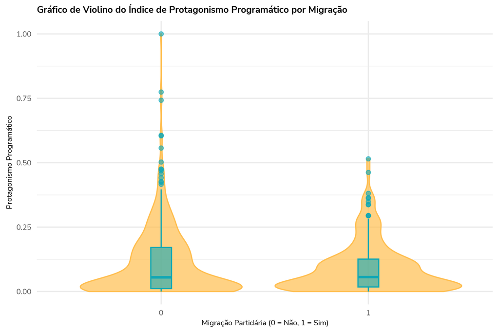

## Resumo dos achados e considerações finais

A despeito de os testes estatísticos não terem falseado a hipótese nula, ainda pende estender as análises para outras legislaturas e, sobretudo, testar se o comportamento migratório relaciona-se, em alguma medida, à distância ideológica entre o parlamentar e seu partido.

## Próximos passos

- Testar o índice de protagonismo programático e sua relação com a migração partidária para outras legislaturas;
- Construir e testar o índice de protagonismo posicional, com o fito de testar o impacto da ocupação de posições chave dentro da legislatura na migração partidária.